# Homework

Author

Astrid Castro

Published

November 5, 2025

The first two problems in this set refer to the `ISLR2::Carseats` set, which includes simulated sample data for 400 stores selling a particular brand of child carseat. We view this data as a simple random sample from a larger population.

```r
library(tidyverse)
library(ISLR2)
library(ggplot2)
```

## Problem 1

Does this data provide evidence against the company’s claim that the average price of their own seats is $110? Follow all best practices from class, including hypotheses, a relevant visualization, and a conclusion in non-technical language.

### Does the average price of the company’s carseats = $110?

Null hypothesis: $\mu = 110$

Alternative hypothesis: $H_a: \mu \ne 110$

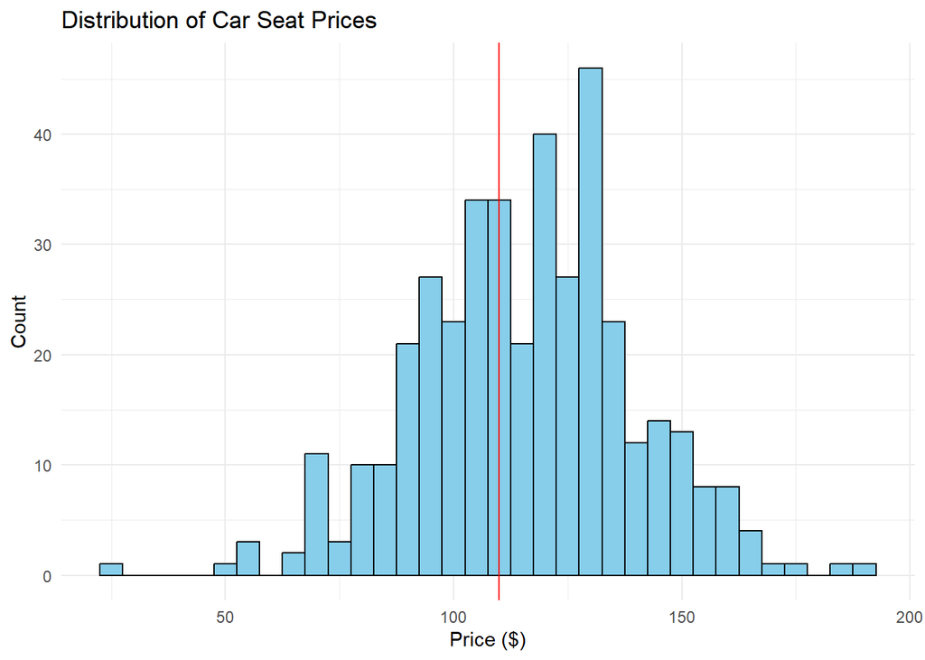

```r
ggplot(Carseats, aes(x = Price)) +
  geom_histogram(binwidth = 5,
                 fill = "skyblue",
                 color = "black") +
  geom_vline(xintercept = 110,
             color = "red") +
  labs(title = "Distribution of Car Seat Prices",
       x = "Price ($)",
       y = "Count") +
  theme_minimal() +
  scale_fill_brewer(palette = "Dark2")
```

```r
t.test(Carseats$Price, mu = 110)
```

```
    One Sample t-test

data:  Carseats$Price
t = 4.8951, df = 399, p-value = 1.429e-06
alternative hypothesis: true mean is not equal to 110
95 percent confidence interval:
 113.4677 118.1223
sample estimates:
mean of x
  115.795
```

## Problem 2

Compute a level 90% confidence interval for the mean competitor price in the population from which this sample is drawn. What is the sample mean? What is the margin of error?

```r
t.test(Carseats$CompPrice, conf.level = 0.90)
```

```
    One Sample t-test

data:  Carseats$CompPrice
t = 163, df = 399, p-value < 2.2e-16
alternative hypothesis: true mean is not equal to 0
90 percent confidence interval:
 123.7109 126.2391
sample estimates:
mean of x
  124.975
```

Mean = 124.975

90% CI = [123.7109, 126.2391]

MOE = 1.2641

## Problem 3

Create a table with counts of penguin species and home islands in the penguins set. Include marginal counts in your table.

```r
table_species_island <- table(penguins$species,
                              penguins$island)

table_with_margins <- addmargins(table_species_island)


table_with_margins
```

```
            Biscoe Dream Torgersen Sum
  Adelie        44    56        52 152
  Chinstrap      0    68         0  68
  Gentoo       124     0         0 124
  Sum          168   124        52 344
```